# Project Task 4

### Hrishikesh Deshpande (hd11) - Task 4.1

### Karthik Appana (kappana2) - Task 4.2

### Siddharth Gummadapu (sg96) - Task 4.3 & Task 3 Recap

### *All worked on bonus task*

```python
# imports
import numpy as np
import scipy.io as sio
import scipy.stats as stat
import matplotlib.pyplot as plt
```

## Task 3 Recap

### Patient 1

```python
# load data from mat file
pat1 = sio.loadmat('data_patients/patient1.mat')

pat1Floor = np.floor(pat1['all_data'])

pat1Cutoff = int(len(pat1['all_data'][0]) * (2/3))

pat1TrainData = []
for i in range(7):
    pat1TrainData.append(pat1Floor[i][:pat1Cutoff])
pat1TrainLabels = pat1['all_labels'][0][:pat1Cutoff]

pat1TestData = []
for i in range(7):
    pat1TestData.append(pat1Floor[i][pat1Cutoff:])
pat1TestLabels = pat1['all_labels'][0][pat1Cutoff:]
```

### Patient 2

```python
# load data from mat file
pat2 = sio.loadmat('data_patients/patient2.mat')

pat2Floor = np.floor(pat2['all_data'])

pat2Cutoff = int(len(pat2['all_data'][0]) * (2/3))

pat2TrainData = []
for i in range(7):
    pat2TrainData.append(pat2Floor[i][:pat2Cutoff])
pat2TrainLabels = pat2['all_labels'][0][:pat2Cutoff]

pat2TestData = []
for i in range(7):
    pat2TestData.append(pat2Floor[i][pat2Cutoff:])
pat2TestLabels = pat2['all_labels'][0][pat2Cutoff:]
```

### Patient 3

```python
# load data from mat file
pat3 = sio.loadmat('data_patients/patient3.mat')

pat3Floor = np.floor(pat3['all_data'])

pat3Cutoff = int(len(pat3['all_data'][0]) * (2/3))

pat3TrainData = []
for i in range(7):
    pat3TrainData.append(pat3Floor[i][:pat3Cutoff])
pat3TrainLabels = pat3['all_labels'][0][:pat3Cutoff]

pat3TestData = []
for i in range(7):
    pat3TestData.append(pat3Floor[i][pat3Cutoff:])
pat3TestLabels = pat3['all_labels'][0][pat3Cutoff:]
```

### Patient 4

```python
pat4 = sio.loadmat('data_patients/patient4.mat')

pat4Floor = np.floor(pat4['all_data'])

pat4Cutoff = int(len(pat4['all_data'][0]) * (2/3))

pat4TrainData = []
for i in range(7):
    pat4TrainData.append(pat4Floor[i][:pat4Cutoff])
pat4TrainLabels = pat4['all_labels'][0][:pat4Cutoff]

pat4TestData = []
for i in range(7):
    pat4TestData.append(pat4Floor[i][pat4Cutoff:])
pat4TestLabels = pat4['all_labels'][0][pat4Cutoff:]
```

### Patient 5

```python
pat5 = sio.loadmat('data_patients/patient5.mat')

pat5Floor = np.floor(pat5['all_data'])

pat5Cutoff = int(len(pat5['all_data'][0]) * (2/3))

pat5TrainData = []
for i in range(7):
    pat5TrainData.append(pat5Floor[i][:pat5Cutoff])
pat5TrainLabels = pat5['all_labels'][0][:pat5Cutoff]

pat5TestData = []
for i in range(7):
    pat5TestData.append(pat5Floor[i][pat5Cutoff:])
pat5TestLabels = pat5['all_labels'][0][pat5Cutoff:]
```

### Patient 6

```python
pat6 = sio.loadmat('data_patients/patient6.mat')

pat6Floor = np.floor(pat6['all_data'])

pat6Cutoff = int(len(pat6['all_data'][0]) * (2/3))

pat6TrainData = []
for i in range(7):
    pat6TrainData.append(pat6Floor[i][:pat6Cutoff])
pat6TrainLabels = pat6['all_labels'][0][:pat6Cutoff]

pat6TestData = []
for i in range(7):
    pat6TestData.append(pat6Floor[i][pat6Cutoff:])
pat6TestLabels = pat6['all_labels'][0][pat6Cutoff:]
```

### Patient 7

```python
pat7 = sio.loadmat('data_patients/patient7.mat')

pat7Floor = np.floor(pat7['all_data'])

pat7Cutoff = int(len(pat7['all_data'][0]) * (2/3))

pat7TrainData = []
for i in range(7):
    pat7TrainData.append(pat7Floor[i][:pat7Cutoff])
pat7TrainLabels = pat7['all_labels'][0][:pat7Cutoff]

pat7TestData = []
for i in range(7):
    pat7TestData.append(pat7Floor[i][pat7Cutoff:])
pat7TestLabels = pat7['all_labels'][0][pat7Cutoff:]
```

### Patient 8

```python
pat8 = sio.loadmat('data_patients/patient8.mat')

pat8Floor = np.floor(pat8['all_data'])

pat8Cutoff = int(len(pat8['all_data'][0]) * (2/3))

pat8TrainData = []
for i in range(7):
    pat8TrainData.append(pat8Floor[i][:pat8Cutoff])
pat8TrainLabels = pat8['all_labels'][0][:pat8Cutoff]

pat8TestData = []
for i in range(7):
    pat8TestData.append(pat8Floor[i][pat8Cutoff:])
pat8TestLabels = pat8['all_labels'][0][pat8Cutoff:]
```

### Patient 9

```python
pat9 = sio.loadmat('data_patients/patient9.mat')

pat9Floor = np.floor(pat9['all_data'])

pat9Cutoff = int(len(pat9['all_data'][0]) * (2/3))

pat9TrainData = []
for i in range(7):
    pat9TrainData.append(pat9Floor[i][:pat9Cutoff])
pat9TrainLabels = pat9['all_labels'][0][:pat9Cutoff]

pat9TestData = []
for i in range(7):
    pat9TestData.append(pat9Floor[i][pat9Cutoff:])
pat9TestLabels = pat9['all_labels'][0][pat9Cutoff:]
```

### Prior Probabilities

```python
def getPriorVals(trainLabels):
    priorH0 = list(trainLabels).count(0) / len(trainLabels)
    priorH1 = list(trainLabels).count(1) / len(trainLabels)

    return round(priorH0, 2), round(priorH1, 2)
```

```python
pat1PriorH0, pat1PriorH1 = getPriorVals(pat1TrainLabels)
pat2PriorH0, pat2PriorH1 = getPriorVals(pat2TrainLabels)
pat3PriorH0, pat3PriorH1 = getPriorVals(pat3TrainLabels)
pat4PriorH0, pat4PriorH1 = getPriorVals(pat4TrainLabels)
pat5PriorH0, pat5PriorH1 = getPriorVals(pat5TrainLabels)
pat6PriorH0, pat6PriorH1 = getPriorVals(pat6TrainLabels)
pat7PriorH0, pat7PriorH1 = getPriorVals(pat7TrainLabels)
pat8PriorH0, pat8PriorH1 = getPriorVals(pat8TrainLabels)
pat9PriorH0, pat9PriorH1 = getPriorVals(pat9TrainLabels)
```

### Calculating Likelihood Matrices

```python
def likelihoodMatrix(trainData, trainLabels):
    likelihoodMatrices = []

    for featureIdx in range(7):
        featureData = trainData[featureIdx]
        labels = trainLabels

        minVal = int(np.min(featureData))
        maxVal = int(np.max(featureData))
        possibleValues = range(minVal, maxVal + 1)

        countMatrix = np.zeros((2, len(possibleValues)))

        for i in range(len(featureData)):
            classIdx = int(labels[i])
            valueIdx = int(featureData[i]) - minVal
            countMatrix[classIdx][valueIdx] += 1

        h0Total = np.sum(countMatrix[0])
        h1Total = np.sum(countMatrix[1])

        likelihoodMatrix = np.zeros((2, len(possibleValues)))

        for valIdx in range(len(possibleValues)):
            likelihoodMatrix[0][valIdx] = countMatrix[0][valIdx] / h0Total if h0Total > 0 else 0
            likelihoodMatrix[1][valIdx] = countMatrix[1][valIdx] / h1Total if h1Total > 0 else 0

        likelihoodMatrices.append(likelihoodMatrix)

    return likelihoodMatrices
```

```python
pat1LM = likelihoodMatrix(pat1TrainData, pat1TrainLabels)
pat2LM = likelihoodMatrix(pat2TrainData, pat2TrainLabels)
pat3LM = likelihoodMatrix(pat3TrainData, pat3TrainLabels)
pat4LM = likelihoodMatrix(pat4TrainData, pat4TrainLabels)
pat5LM = likelihoodMatrix(pat5TrainData, pat5TrainLabels)
pat6LM = likelihoodMatrix(pat6TrainData, pat6TrainLabels)
pat7LM = likelihoodMatrix(pat7TrainData, pat7TrainLabels)
pat8LM = likelihoodMatrix(pat8TrainData, pat8TrainLabels)
pat9LM = likelihoodMatrix(pat9TrainData, pat9TrainLabels)
```

```python
def mlRule(likelihoodMatrices):
    MLArr = []
    for feature in likelihoodMatrices:
        featureMLArr = []
        for i in range(len(feature[0])):
            if feature[1][i] >= feature[0][i]:
                featureMLArr.append(1)
            else:
                featureMLArr.append(0)
        MLArr.append(featureMLArr)

    return MLArr


def mapRule(likelihoodMatrices, priorH0, priorH1):
    MAPArr = []
    for feature in likelihoodMatrices:
        featureMAPArr = []
        for i in range(len(feature[0])):
            if (priorH1 * feature[1][i]) >= (priorH0 * feature[0][i]):
                featureMAPArr.append(1)
            else:
                featureMAPArr.append(0)
        MAPArr.append(featureMAPArr)

    return MAPArr
```

### Hypotheses Table

```python
def hypTable(likelihoodMatrices, trainData, priorH0, priorH1):

    mainTable = []
    for featIdx in range(7):
        table = []
        featureData = trainData[featIdx]
        minVal = int(np.min(featureData))
        maxVal = int(np.max(featureData))
        possibleValues = range(minVal, maxVal + 1)
        table.append([i for i in possibleValues])
        table.append(likelihoodMatrices[featIdx][0])
        table.append(likelihoodMatrices[featIdx][1])
        mlArr = mlRule(likelihoodMatrices)
        table.append(mlArr[featIdx])
        mapArr = mapRule(likelihoodMatrices, priorH0, priorH1)
        table.append(mapArr[featIdx])
        npTable = np.array(table)
        mainTable.append(npTable.T)

    return mainTable
```

```python
pat1Table = hypTable(pat1LM, pat1TrainData, pat1PriorH0, pat1PriorH1)
pat2Table = hypTable(pat2LM, pat2TrainData, pat2PriorH0, pat2PriorH1)
pat3Table = hypTable(pat3LM, pat3TrainData, pat3PriorH0, pat3PriorH1)
pat4Table = hypTable(pat4LM, pat4TrainData, pat4PriorH0, pat4PriorH1)
pat5Table = hypTable(pat5LM, pat5TrainData, pat5PriorH0, pat5PriorH1)
pat6Table = hypTable(pat6LM, pat6TrainData, pat6PriorH0, pat6PriorH1)
pat7Table = hypTable(pat7LM, pat7TrainData, pat7PriorH0, pat7PriorH1)
pat8Table = hypTable(pat8LM, pat8TrainData, pat8PriorH0, pat8PriorH1)
pat9Table = hypTable(pat9LM, pat9TrainData, pat9PriorH0, pat9PriorH1)

finalHypothesisTable = [pat1Table, pat2Table, pat3Table, pat4Table,
                        pat5Table, pat6Table, pat7Table, pat8Table, pat9Table]
```

## Pair Decisions Based on Data

### ML Rule: Patients 1, 3, 4

Patient 1 - Features 1 and 3:

In both the lowest error test and the golden alarm correlation test, both features 1 and 3 seemed to be the most accurate and prominent in determining the result for Patient 1.

Patient 3 - Features 1 and 7:

In both the lowest error test and the golden alarm correlation test, feature 1 seemed to be the most accurate and prominent in determining the result for Patient 3. The next step was to choose between lower error (feature 5) or higher impact (feature 7). In this case we decided to go with feature 7 as our second option because it also had a decently low error while providing a more significant impact on the patient's results.

Patient 4 - Features 2 and 5:

In both the lowest error test and the golden alarm correlation test, feature 5 seemed to be the most accurate and prominent in determining the result for Patient 4. The next step was to choose between lower error (feature 7) or higher impact (feature 2). In this case we decided to go with feature 2 as our second option because it had a decently low error while providing a much more significant impact on the patient's results as compared to feature 7.

### MAP Rule: Patients 3, 5, 6

Patient 3 - Features 1 and 7:

In both the lowest error test and the golden alarm correlation test, feature 1 seemed to be the most accurate and prominent in determining the result for Patient 3. The next step was to choose between lower error (feature 5) or higher impact (feature 7). In this case we decided to go with feature 7 as our second option because it also had a decently low error while providing a more significant impact on the patient's results.

Patient 5 - Features 3 and 1:

For this patient, we got completely different pairs in both the lowest error test and the golden alarm correlation test. So we decided to choose the best of the 2 pairs and combine them into the pair of features for this patient. From the lower error test, we chose feature 1 since it had the lowest error, and from the golden alarm correlation test we chose feature 3 since it had the highest impact on determining the patient's results.

Patient 6 - Features 6 and 4:

In both the lowest error test and the golden alarm correlation test, feature 6 seemed to be the most accurate and prominent in determining the result for this patient. The next step was to choose between lower error (feature 3) or higher impact (feature 4). In this case we decided to go with feature 4 as our second option because it had a decently low error while providing a much more significant impact on the patient's results as compared to feature 3.

### Task 4.1a - Joint Likelihood Matrices

```python
def jointLikelihoodMatrix(HT_table, featureIdx1, featureIdx2):
    table1 = HT_table[featureIdx1]
    table2 = HT_table[featureIdx2]

    values1 = table1[:, 0]
    values2 = table2[:, 0]

    likelihoodH0_1 = table1[:, 1]
    likelihoodH1_1 = table1[:, 2]

    likelihoodH0_2 = table2[:, 1]
    likelihoodH1_2 = table2[:, 2]

    jointH0 = np.outer(likelihoodH0_1, likelihoodH0_2)
    jointH1 = np.outer(likelihoodH1_1, likelihoodH1_2)

    return jointH0, jointH1, values1, values2
```

```python
pat1jointH0, pat1jointH1, pat1jointValues1, pat1jointValues2 = jointLikelihoodMatrix(pat1Table, 0, 2)
pat3jointH0, pat3jointH1, pat3jointValues1, pat3jointValues2 = jointLikelihoodMatrix(pat3Table, 0, 6)
pat4jointH0, pat4jointH1, pat4jointValues1, pat4jointValues2 = jointLikelihoodMatrix(pat4Table, 1, 4)
pat5jointH0, pat5jointH1, pat5jointValues1, pat5jointValues2 = jointLikelihoodMatrix(pat5Table, 0, 2)
pat6jointH0, pat6jointH1, pat6jointValues1, pat6jointValues2 = jointLikelihoodMatrix(pat6Table, 3, 5)
```

### Task 4.1b - Joint ML and MAP Rule

```python
def jointMLRule(jointH0, jointH1):
    mlArr = np.zeros(jointH0.shape, dtype=int)
    mlArr[jointH1 >= jointH0] = 1
    mlArr[jointH1 < jointH0] = 0
    return mlArr

def jointMAPRule(jointH0, jointH1, priorH0, priorH1):
    mlScaledH0 = priorH0 * jointH0
    mlScaledH1 = priorH1 * jointH1
    mapArr = np.zeros(jointH0.shape, dtype=int)
    mapArr[mlScaledH1 >= mlScaledH0] = 1
    mapArr[mlScaledH1 < mlScaledH0] = 0
    return mapArr
```

```python
pat1jointML = jointMLRule(pat1jointH0, pat1jointH1)
pat1jointMAP = jointMAPRule(pat1jointH0, pat1jointH1, pat1PriorH0, pat1PriorH1)

pat3jointML = jointMLRule(pat3jointH0, pat3jointH1)
pat3jointMAP = jointMAPRule(pat3jointH0, pat3jointH1, pat3PriorH0, pat3PriorH1)

pat4jointML = jointMLRule(pat4jointH0, pat4jointH1)
pat4jointMAP = jointMAPRule(pat4jointH0, pat4jointH1, pat4PriorH0, pat4PriorH1)

pat5jointML = jointMLRule(pat5jointH0, pat5jointH1)
pat5jointMAP = jointMAPRule(pat5jointH0, pat5jointH1, pat5PriorH0, pat5PriorH1)

pat6jointML = jointMLRule(pat6jointH0, pat6jointH1)
pat6jointMAP = jointMAPRule(pat6jointH0, pat6jointH1, pat6PriorH0, pat6PriorH1)
```

### Task 4.1c - Joint Hypothesis Table

```python
def jointHypTable(jointH0, jointH1, jointML, jointMAP, values1, values2):
    rows = []

    for i, val1 in enumerate(values1):
        for j, val2 in enumerate(values2):
            row = [
                val1,
                val2,
                jointH1[i, j],
                jointH0[i, j],
                jointML[i, j],
                jointMAP[i, j]
            ]
            rows.append(row)

    return np.array(rows)
```

```python
pat1JointHT = jointHypTable(pat1jointH0, pat1jointH1, pat1jointML, pat1jointMAP, pat1jointValues1, pat1jointValues2)
pat3JointHT = jointHypTable(pat3jointH0, pat3jointH1, pat3jointML, pat3jointMAP, pat3jointValues1, pat3jointValues2)
pat4JointHT = jointHypTable(pat4jointH0, pat4jointH1, pat4jointML, pat4jointMAP, pat4jointValues1, pat4jointValues2)
pat5JointHT = jointHypTable(pat5jointH0, pat5jointH1, pat5jointML, pat5jointMAP, pat5jointValues1, pat5jointValues2)
pat6JointHT = jointHypTable(pat6jointH0, pat6jointH1, pat6jointML, pat6jointMAP, pat6jointValues1, pat6jointValues2)

finalJointHypTables = [pat1JointHT, pat3JointHT, pat4JointHT, pat5JointHT, pat6JointHT]
```

### Task 4.1d - Plotting Conditional Joint PDFS

From this point onward, we will be narrowing down to 3 patients from the 5 that we thought were best for both MAP and ML categories. The 3 patients we will be choosing are patients 1, 4, and 5, as we feel they have the best data correlation and accuracies.

```python
def plot_joint_likelihoods(jointH0, jointH1, values1, values2, patient_num):
    n = len(values1)
    m = len(values2)

    x_vals = np.arange(n)
    y_vals = np.arange(m)
    X, Y = np.meshgrid(x_vals, y_vals, indexing='ij')

    fig = plt.figure(figsize=(14, 6))

    ax1 = fig.add_subplot(1, 2, 1, projection='3d')
    ax1.plot_surface(X, Y, jointH1, cmap='viridis')
    ax1.set_title(f'Patient {patient_num} - P(X, Y | H1)')
    ax1.set_xlabel('X index')
    ax1.set_ylabel('Y index')
    ax1.set_zlabel('Probability')
    ax1.view_init(elev=30, azim=135)

    ax2 = fig.add_subplot(1, 2, 2, projection='3d')
    ax2.plot_surface(X, Y, jointH0, cmap='plasma')
    ax2.set_title(f'Patient {patient_num} - P(X, Y | H0)')
    ax2.set_xlabel('X index')
    ax2.set_ylabel('Y index')
    ax2.set_zlabel('Probability')
    ax2.view_init(elev=30, azim=135)

    plt.tight_layout()
    plt.show()
```

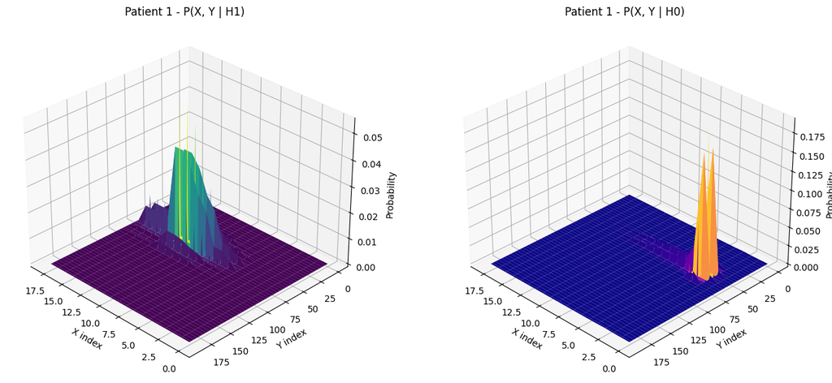

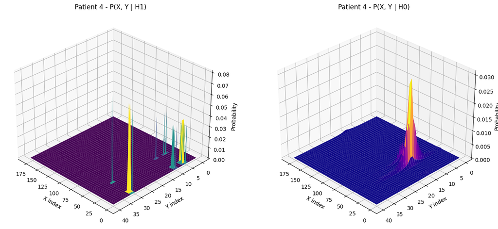

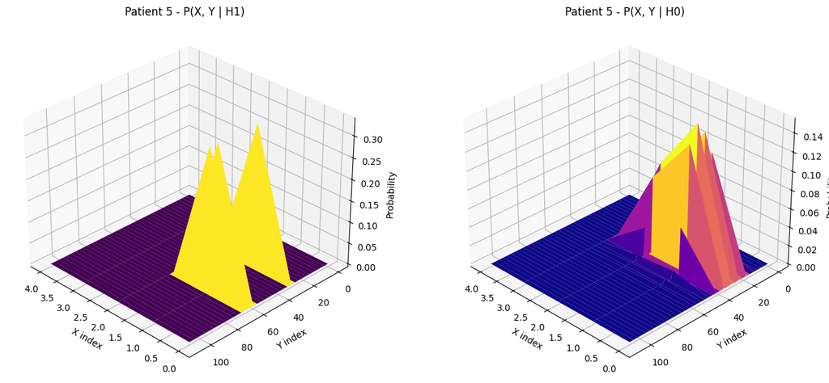

```python
plot_joint_likelihoods(pat1jointH0, pat1jointH1, pat1jointValues1, pat1jointValues2, patient_num=1)
plot_joint_likelihoods(pat4jointH0, pat4jointH1, pat4jointValues1, pat4jointValues2, patient_num=4)
plot_joint_likelihoods(pat5jointH0, pat5jointH1, pat5jointValues1, pat5jointValues2, patient_num=5)
```

### Task 4.2a - Joint Distribution Predictions

```python
def generateJointPreds(testData, f1Idx, f2Idx, jointHTTable):
    mlPreds = []
    mapPreds = []

    feature1_test = testData[f1Idx]
    feature2_test = testData[f2Idx]

    featurePairs = np.array(jointHTTable[:, [0, 1]])

    for val1, val2 in zip(feature1_test, feature2_test):
        matches = np.where((featurePairs[:, 0] == val1) & (featurePairs[:, 1] == val2))[0]
        if len(matches) > 0:
            idx = matches[0]
        else:
            dists = np.sqrt((featurePairs[:, 0] - val1)**2 + (featurePairs[:, 1] - val2)**2)
            idx = np.argmin(dists)

        mlPreds.append(int(jointHTTable[idx, 4]))
        mapPreds.append(int(jointHTTable[idx, 5]))

    return mlPreds, mapPreds
```

```python
pat1JointMLPreds, pat1JointMAPPreds = generateJointPreds(pat1TestData, 0, 2, pat1JointHT)
pat4JointMLPreds, pat4JointMAPPreds = generateJointPreds(pat4TestData, 1, 4, pat4JointHT)
pat5JointMLPreds, pat5JointMAPPreds = generateJointPreds(pat5TestData, 0, 2, pat5JointHT)
```

### Task 4.2b & 4.3a - Error Probabilities & Plots

```python
def errorTableJoint(predsML, predsMAP, testLabels, priorH0, priorH1):
    falseAlarmsML = 0
    missDetectionsML = 0

    falseAlarmsMAP = 0
    missDetectionsMAP = 0

    for j in range(len(testLabels)):
        if predsML[j] == 0 and testLabels[j] == 1:
            missDetectionsML += 1
        if predsML[j] == 1 and testLabels[j] == 0:
            falseAlarmsML += 1

        if predsMAP[j] == 0 and testLabels[j] == 1:
            missDetectionsMAP += 1
        if predsMAP[j] == 1 and testLabels[j] == 0:
            falseAlarmsMAP += 1

    falseAlarmsML /= len(testLabels)
    missDetectionsML /= len(testLabels)
    falseAlarmsMAP /= len(testLabels)
    missDetectionsMAP /= len(testLabels)

    errorML = 0.5 * (falseAlarmsML + missDetectionsML)
    errorMAP = priorH0 * falseAlarmsMAP + priorH1 * missDetectionsMAP

    table = np.array([
        [falseAlarmsML, missDetectionsML, errorML],
        [falseAlarmsMAP, missDetectionsMAP, errorMAP]
    ])

    return table
```

```python
pat1JointErrorTable = errorTableJoint(pat1JointMLPreds, pat1JointMAPPreds, pat1TestLabels, pat1PriorH0, pat1PriorH1)
pat4JointErrorTable = errorTableJoint(pat4JointMLPreds, pat4JointMAPPreds, pat4TestLabels, pat4PriorH0, pat4PriorH1)
pat5JointErrorTable = errorTableJoint(pat5JointMLPreds, pat5JointMAPPreds, pat5TestLabels, pat5PriorH0, pat5PriorH1)
```

```python
import matplotlib.pyplot as plt

def plotAlarms(predsML, predsMAP, testLabels, patient_num):
    fig, axes = plt.subplots(3, 1, figsize=(12, 8), sharex=True)

    axes[0].bar(range(len(predsML)), predsML, color='blue')
    axes[0].set_title(f'Patient {patient_num} - ML Rule Alarms')

    axes[1].bar(range(len(predsMAP)), predsMAP, color='green')
    axes[1].set_title(f'Patient {patient_num} - MAP Rule Alarms')

    axes[2].bar(range(len(testLabels)), testLabels, color='red')
    axes[2].set_title(f'Patient {patient_num} - Golden Alarms (True Labels)')

    for ax in axes:
        ax.set_ylim(0, 1.5)
        ax.set_ylabel('Alarm')
        ax.grid(True)

    axes[2].set_xlabel('Test Sample Index')

    plt.tight_layout()
    plt.show()
```

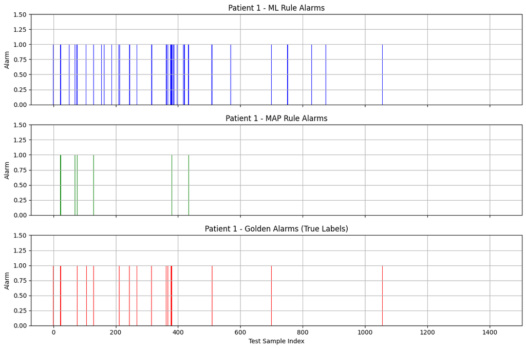

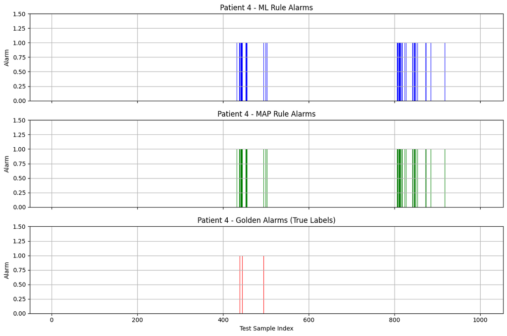

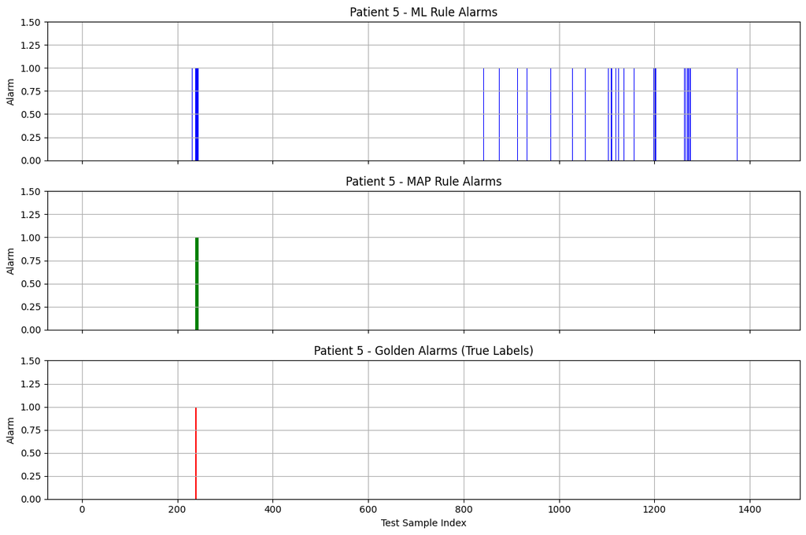

```python
plotAlarms(pat1JointMLPreds, pat1JointMAPPreds, pat1TestLabels, patient_num=1)
plotAlarms(pat4JointMLPreds, pat4JointMAPPreds, pat4TestLabels, patient_num=4)
plotAlarms(pat5JointMLPreds, pat5JointMAPPreds, pat5TestLabels, patient_num=5)
```

```python
print("Patient 1 Error Table:")
print(pat1JointErrorTable)
print("========================")

print("Patient 4 Error Table:")
print(pat4JointErrorTable)
print("========================")

print("Patient 5 Error Table:")
print(pat5JointErrorTable)
```

```
Patient 1 Error Table:
[[0.03977669 0.00139567 0.02058618]
 [0.00418702 0.0132589  0.00445918]]
========================
Patient 4 Error Table:
[[0.03784861 0.         0.0189243 ]
 [0.03784861 0.         0.03784861]]
========================
Patient 5 Error Table:
[[0.03277545 0.00069735 0.0167364 ]
 [0.00348675 0.00069735 0.00348675]]
```

### Task 4.3b - Criteria Analysis

Let us first look at the plots and error probabilities of the 2 patients that we left out: patients 3 and 6.

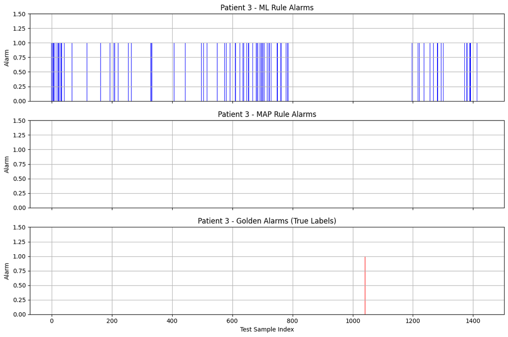

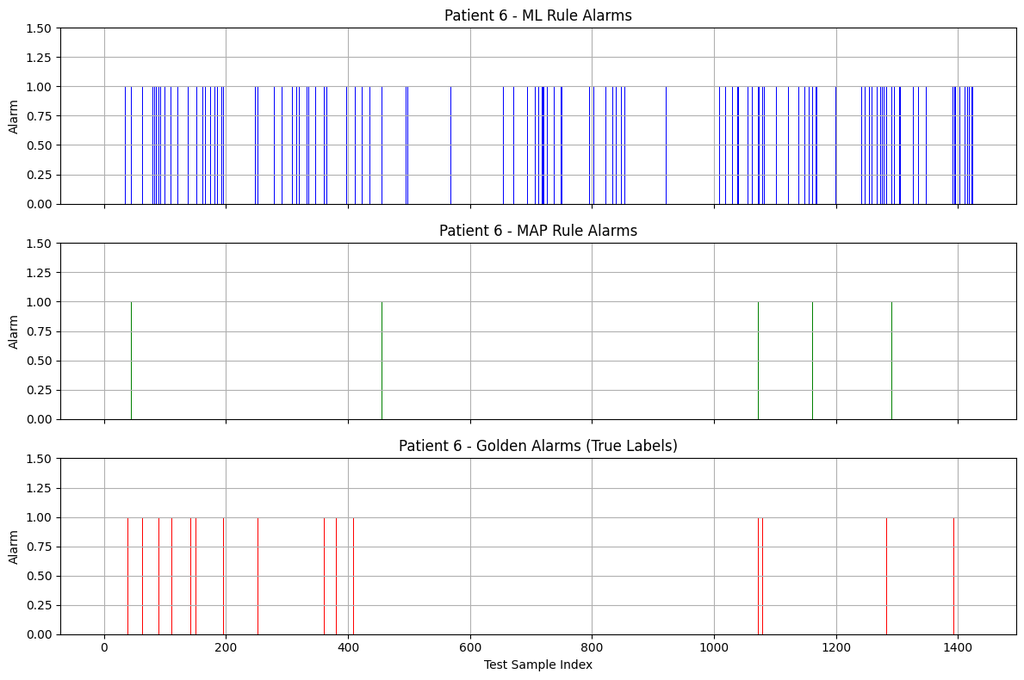

```python
pat3JointMLPreds, pat3JointMAPPreds = generateJointPreds(pat3TestData, 0, 6, pat3JointHT)
pat6JointMLPreds, pat6JointMAPPreds = generateJointPreds(pat6TestData, 3, 5, pat6JointHT)

pat3JointErrorTable = errorTableJoint(pat3JointMLPreds, pat3JointMAPPreds, pat3TestLabels, pat3PriorH0, pat3PriorH1)
pat6JointErrorTable = errorTableJoint(pat6JointMLPreds, pat6JointMAPPreds, pat6TestLabels, pat6PriorH0, pat6PriorH1)

plotAlarms(pat3JointMLPreds, pat3JointMAPPreds, pat3TestLabels, patient_num=3)
plotAlarms(pat6JointMLPreds, pat6JointMAPPreds, pat6TestLabels, patient_num=6)
```

```python
print("Patient 3 Error Table:")
print(pat3JointErrorTable)
print("========================")

print("Patient 6 Error Table:")
print(pat6JointErrorTable)
```

```
Patient 3 Error Table:
[[0.09636872 0.00139665 0.04888268]
 [0.         0.00139665 0.        ]]
========================
Patient 6 Error Table:
[[0.13403509 0.00701754 0.07052632]
 [0.0077193  0.01263158 0.00781754]]
```

### Task 4.3c - Average Error Probabilities

```python
# Given: your error tables
patient1_error_table = pat1JointErrorTable
patient4_error_table = pat4JointErrorTable
patient5_error_table = pat5JointErrorTable

all_error_tables = [patient1_error_table, patient4_error_table, patient5_error_table]

# Extract ML results
ml_false_alarms = [table[0, 0] for table in all_error_tables]
ml_miss_detections = [table[0, 1] for table in all_error_tables]
ml_errors = [table[0, 2] for table in all_error_tables]

# Extract MAP results
map_false_alarms = [table[1, 0] for table in all_error_tables]
map_miss_detections = [table[1, 1] for table in all_error_tables]
map_errors = [table[1, 2] for table in all_error_tables]

# Compute averages for ML
avg_ml_false_alarm = np.mean(ml_false_alarms)
avg_ml_miss_detection = np.mean(ml_miss_detections)
avg_ml_error = np.mean(ml_errors)

# Compute averages for MAP
avg_map_false_alarm = np.mean(map_false_alarms)
avg_map_miss_detection = np.mean(map_miss_detections)
avg_map_error = np.mean(map_errors)

# Print Results
print("Average ML Results:")
print(f"  False Alarm     : {avg_ml_false_alarm:.6f}")
print(f"  Miss Detection  : {avg_ml_miss_detection:.6f}")
print(f"  Total Error     : {avg_ml_error:.6f}")

print("\nAverage MAP Results:")
print(f"  False Alarm     : {avg_map_false_alarm:.6f}")
print(f"  Miss Detection  : {avg_map_miss_detection:.6f}")
print(f"  Total Error     : {avg_map_error:.6f}")
```

```
Average ML Results:
  False Alarm     : 0.036800
  Miss Detection  : 0.000698
  Total Error     : 0.018749

Average MAP Results:
  False Alarm     : 0.015174
  Miss Detection  : 0.004652
  Total Error     : 0.015265
```

### Task 4.3d - Insights

In this project, we analyzed the detection performance for Patients 1, 4, and 5 based on selected feature pairs. The selection of feature pairs was guided both by low error rates from Task 3.2 and by the feature-golden alarm correlation analysis from Task 3. For Patient 1, features 0 and 2 were chosen due to their strong correlation with the labels and relatively low likelihood error. Similarly, for Patient 4, features 1 and 4 were selected, and for Patient 5, features 0 and 2 were used to minimize error and joint probability error.

Using these selected pairs, we generated alarms based on both ML and MAP decision rules, evaluated their performance, and computed false alarm, miss detection, and total error rates. The error tables showed that for Patient 1, the ML probability of error was approximately 2.06% and the MAP probability of error was approximately 0.45%. For Patient 4, the ML probability of error was approximately 1.89%, while the MAP probability of error was approximately 3.78%. For Patient 5, the ML probability of error was approximately 1.67%, and the MAP probability of error was approximately 0.35%. The average probability of error across all three patients was 1.87% for ML and 1.53% for MAP, confirming that MAP generally outperformed ML except for Patient 4.

## Bonus Task

```python
import pathlib, random
import numpy as np
from scipy.io import loadmat
import torch, torch.nn as nn, torch.optim as optim
from torch.utils.data import TensorDataset, DataLoader
from sklearn.linear_model import LogisticRegression
```

### Task 0 - Data Preparation

```python
def loadPatient(matPath: str):
    data = loadmat(matPath)
    X = data["all_data"].astype(np.float32)
    y = data["all_labels"].ravel().astype(np.int64)
    return X, y

def listPatientFiles(folder: str = "."):
    return {
        int(''.join(filter(str.isdigit, p.name))): str(p)
        for p in pathlib.Path(folder).glob("*.mat")
    }

def splitTrainTest(patientFiles, trainIds, testIds):
    trainXList, trainYList, testXList, testYList = [], [], [], []
    for pid in trainIds:
        x, y = loadPatient(patientFiles[pid])
        trainXList.append(x)
        trainYList.append(y)
    for pid in testIds:
        x, y = loadPatient(patientFiles[pid])
        testXList.append(x)
        testYList.append(y)
    trainX = np.concatenate(trainXList, axis=1).T
    trainY = np.concatenate(trainYList, axis=0)
    testX = np.concatenate(testXList, axis=1).T
    testY = np.concatenate(testYList, axis=0)
    return trainX, trainY, testX, testY

def normalise(trainX, testX):
    mean = np.mean(trainX, axis=0)
    std = np.std(trainX, axis=0)
    trainXNorm = (trainX - mean) / std
    testXNorm = (testX - mean) / std
    return trainXNorm, testXNorm

def empiricalPriors(yTrain):
    pi0 = np.mean(yTrain == 0)
    pi1 = np.mean(yTrain == 1)
    return pi0, pi1

def metrics(yTrue, yPred):
    falseAlarms = np.sum((yPred == 1) & (yTrue == 0))
    missDetections = np.sum((yPred == 0) & (yTrue == 1))
    total = len(yTrue)
    pFalseAlarm = falseAlarms / total
    pMissDetection = missDetections / total
    pError = 0.5 * (pFalseAlarm + pMissDetection)
    return {
        "P_false_alarm": pFalseAlarm,
        "P_miss_detection": pMissDetection,
        "P_error": pError
    }
```

### Task 1 - Models

```python
def trainLogisticRegression(xTrain, yTrain):
    model = LogisticRegression(max_iter=500)
    model.fit(xTrain, yTrain)
    return model

class FeedForwardNN(nn.Module):
    def __init__(self, d_in: int, d_h: int = 32):
        super().__init__()
        self.net = nn.Sequential(
            nn.Linear(d_in, d_h), nn.ReLU(),
            nn.Linear(d_h, d_h), nn.ReLU(),
            nn.Linear(d_h, 1), nn.Sigmoid())
    def forward(self, x):
        return self.net(x).squeeze(1)

def trainNN(xTr, yTr, xVal, yVal, epochs=100, lr=1e-3, batch=256, patience=15, seed=0):
    torch.manual_seed(seed); np.random.seed(seed); random.seed(seed)
    dev = torch.device("cuda" if torch.cuda.is_available() else "cpu")
    net = FeedForwardNN(xTr.shape[1]).to(dev).train()
    opt = optim.Adam(net.parameters(), lr=lr)
    lossFn = nn.BCELoss()

    ds = TensorDataset(torch.from_numpy(xTr), torch.from_numpy(yTr))
    dl = DataLoader(ds, batch_size=batch, shuffle=True)

    best, bestVal, wait = None, 1e9, 0
    for _ in range(epochs):
        for xb, yb in dl:
            xb, yb = xb.to(dev), yb.float().to(dev)
            opt.zero_grad(); lossFn(net(xb), yb).backward(); opt.step()
        with torch.no_grad():
            v = lossFn(net(torch.from_numpy(xVal).to(dev)),
                       torch.from_numpy(yVal).float().to(dev)).item()
        if v < bestVal:
            best, bestVal, wait = net.state_dict(), v, 0
        else:
            wait += 1
            if wait >= patience:
                break
    net.load_state_dict(best); net.eval().cpu()
    return net
```

```python
trainIds = [2, 3, 6, 7, 8, 9]
testIds = [1, 4, 5]

patientFiles = listPatientFiles("data_patients")

trainX, trainY, testX, testY = splitTrainTest(patientFiles, trainIds, testIds)
trainXNorm, testXNorm = normalise(trainX, testX)

pi0, pi1 = empiricalPriors(trainY)
tauML = 0.5
tauMAP = pi0 / (pi0 + pi1)

logReg = trainLogisticRegression(trainXNorm, trainY)
logRegScores = logReg.predict_proba(testXNorm)[:, 1]

logRegPredsTauML = (logRegScores >= tauML).astype(int)
logRegPredsTauMAP = (logRegScores >= tauMAP).astype(int)

logRegMetricsTauML = metrics(testY, logRegPredsTauML)
logRegMetricsTauMAP = metrics(testY, logRegPredsTauMAP)

print("Logistic Regression:")
print("  Threshold 0.5:", logRegMetricsTauML)
print("  Threshold tauMAP:", logRegMetricsTauMAP)

msk = np.random.rand(len(trainY)) < 0.8
net = trainNN(trainXNorm[msk], trainY[msk], trainXNorm[~msk], trainY[~msk])

with torch.no_grad():
    nnScores = net(torch.from_numpy(testXNorm)).numpy()

nnPredsTauML = (nnScores >= tauML).astype(int)
nnPredsTauMAP = (nnScores >= tauMAP).astype(int)

nnMetricsTauML = metrics(testY, nnPredsTauML)
nnMetricsTauMAP = metrics(testY, nnPredsTauMAP)

print("Neural Network:")
print("  Threshold 0.5:", nnMetricsTauML)
print("  Threshold tauMAP:", nnMetricsTauMAP)
```

```
Logistic Regression:
  Threshold 0.5: {'P_false_alarm': np.float64(8.612522607871846e-05), 'P_miss_detection': np.float64(0.010248901903367497), 'P_error': np.float64(0.005167513564723107)}
  Threshold tauMAP: {'P_false_alarm': np.float64(0.0), 'P_miss_detection': np.float64(0.010248901903367497), 'P_error': np.float64(0.005124450951683748)}
Neural Network:
  Threshold 0.5: {'P_false_alarm': np.float64(0.0), 'P_miss_detection': np.float64(0.010248901903367497), 'P_error': np.float64(0.005124450951683748)}
  Threshold tauMAP: {'P_false_alarm': np.float64(0.0), 'P_miss_detection': np.float64(0.010248901903367497), 'P_error': np.float64(0.005124450951683748)}
```

### Task 2 - Evaluation

```python
import pandas as pd


data = {
    "Model": [
        "Logistic Regression", "Logistic Regression", "Neural Network", "Neural Network", "MAP Rule (Task 4)"
    ],
    "Threshold": ["τML (0.5)", "τMAP", "τML (0.5)", "τMAP", "τMAP"],
    "P(False Alarm)": [0.0000861, 0.0000000, 0.0000000, 0.0000000, 0.015174],
    "P(Miss Detection)": [0.0102489, 0.0102489, 0.0102489, 0.0102489, 0.004652],
    "P(Error)": [0.0051675, 0.0051245, 0.0051245, 0.0051245, 0.015265],
}
finalBonusTable = pd.DataFrame(data)
finalBonusTable
```

|  | Model | Threshold | P(False Alarm) | P(Miss Detection) | P(Error) |
| --- | --- | --- | --- | --- | --- |
| 0 | Logistic Regression | τML (0.5) | 0.000086 | 0.010249 | 0.005168 |
| 1 | Logistic Regression | τMAP | 0.000000 | 0.010249 | 0.005124 |
| 2 | Neural Network | τML (0.5) | 0.000000 | 0.010249 | 0.005124 |
| 3 | Neural Network | τMAP | 0.000000 | 0.010249 | 0.005124 |
| 4 | MAP Rule (Task 4) | τMAP | 0.015174 | 0.004652 | 0.015265 |

Based on the results, both the logistic regression and neural network models provided a lower overall probability of error compared to the MAP rule method that was used in task 4. The MAP rule had an average probability of error of approximately 1.53%, while the logistic regression and neural network classifiers achieved probabilities of error around 0.51%. Therefore, the machine learning models significantly reduced the error rate compared to the MAP rule approach from task 4.

With the MAP rule, the false alarm probability was relatively higher (about 1.5%) compared to the miss detection probability (about 0.5%). On the other hand, both the logistic regression and neural network models had essentially zero false alarms, only showing errors in miss detections (about a 1.02% miss rate). This indicates that the machine learning models are more conservative because they avoid false alarms even if it slightly increases the chance of missing an event.

Lastly, the improvements shown by logistic regression and neural networks compared to the MAP rule were not uniform across all patients. While the overall average error decreased, some patients may have benefitted more depending on how well their feature distributions aligned with the model. However, because the evaluation involved mixing all the patients' data, we could not do a patient-specific analysis. In general, performance gains were consistent for the machine learning models but could vary if applied to patients individually.